# Test a Perceptual Phenomenon

### Analyzing the Stroop Effect

Perform the analysis in the space below. Remember to follow [the instructions](https://docs.google.com/document/d/1-OkpZLjG_kX9J6LIQ5IltsqMzVWjh36QpnP2RYpVdPU/pub?embedded=True) and review the [project rubric](https://review.udacity.com/#!/rubrics/71/view) before submitting. Once you've completed the analysis and write-up, download this file as a PDF or HTML file, upload that PDF/HTML into the workspace here (click on the orange Jupyter icon in the upper left then Upload), then use the Submit Project button at the bottom of this page. This will create a zip file containing both this .ipynb doc and the PDF/HTML doc that will be submitted for your project.

(1) What is the independent variable? What is the dependent variable?

- the independent variable is the test condition that is the congruent condition or the incongruent.
- the dependent variable is the time it to takes to name the colors.

(2) What is an appropriate set of hypotheses for this task? Specify your null and alternative hypotheses, and clearly define any notation used. Justify your choices.

> finding whether the mean difference between the two datasets is statically significant.

> $\mu_c$ is the average time taken to name the Congruent words

> $\mu_{in}$ is the average time taken to name the inCongruent words

**the Null hypothesis (H0):** The average time taken to name the color of the incongruent $\mu_{in}$ and the congruent words $\mu_c$ is just the same $$ \mu_{in} -\mu_c = 0 $$

**the Alternative Hypothesis (H1):** The average time taken to name the color of the incongurent words $\mu_{in}$ and the congruent words $\mu_c$ isn't the same and significantly different $$ \mu_{in} -\mu_c \neq 0 $$

> here we will be using the **T-test** because we don't have the population parameters, we have a small sample hence we can use the T-table and we just have samples that we will be using to estimate the population parameter that is the difference between the time averages in each condition.

> on the other hand if we had the Population paramters like the mean and the STD, we could be using the z-test instead.

> here we performed a dependent(paired) T-test because the same sample has performed the test under varying conditions that is the congruent and incongruent words.

(3) Report some descriptive statistics regarding this dataset. Include at least one measure of central tendency and at least one measure of variability. The name of the data file is 'stroopdata.csv'.

```python
import pandas as pd
import numpy as np
import matplotlib.pyplot as plt
df = pd.read_csv('stroopdata.csv')
df.shape
```

```
(24, 2)
```

```python
# the average time
df.mean()
```

```
Congruent      14.051125
Incongruent    22.015917
dtype: float64
```

```python
# the median
df.median()
```

```
Congruent      14.3565
Incongruent    21.0175
dtype: float64
```

```python
# the standard deviation
df.std()
```

```
Congruent      3.559358
Incongruent    4.797057
dtype: float64
```

```python
# the variance
df.var()
```

```
Congruent      12.669029
Incongruent    23.011757
dtype: float64
```

the mean of the congurent words : 14.051125

the mean of the incongurent words : 22.015917

the standard deviation of the congurent words : 3.559358

the standard deviation of the incongurent words : 4.797057

(4) Provide one or two visualizations that show the distribution of the sample data. Write one or two sentences noting what you observe about the plot or plots.

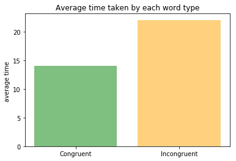

```python
# a bar chart of the two words types average naming time.
avgCongurent = df['Congruent'].mean()
avgInCongurent = df['Incongruent'].mean()
objects = ('Congruent', 'Incongruent')
y_pos = np.arange(len(objects))
performance = [avgCongurent,avgInCongurent]

plt.bar(y_pos, performance, align='center', alpha=0.5,color =['green','orange'])
plt.xticks(y_pos, objects)
plt.ylabel('average time ')
plt.title('Average time taken by each word type')

plt.show()
```

> the average time taken to name the incongruent words is pretty bigger than the congruent words

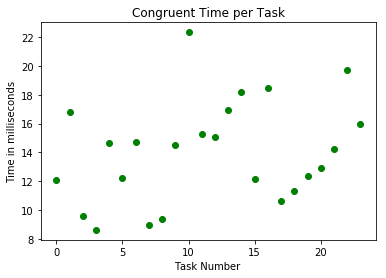

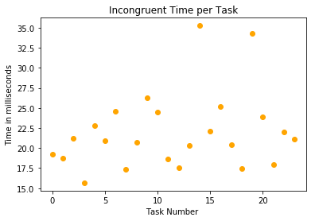

```python
# scatter plot of each distribution
plt.scatter(list(range(len(df['Congruent']))),df['Congruent'],color='green');
plt.ylabel('Time in milliseconds')
plt.xlabel('Task Number ')
plt.title('Congruent Time per Task')
plt.show();

plt.scatter(list(range(len(df['Incongruent']))),df['Incongruent'] , color='orange');
plt.ylabel('Time in milliseconds')
plt.xlabel('Task Number ')
plt.title('Incongruent Time per Task')
plt.show();
```

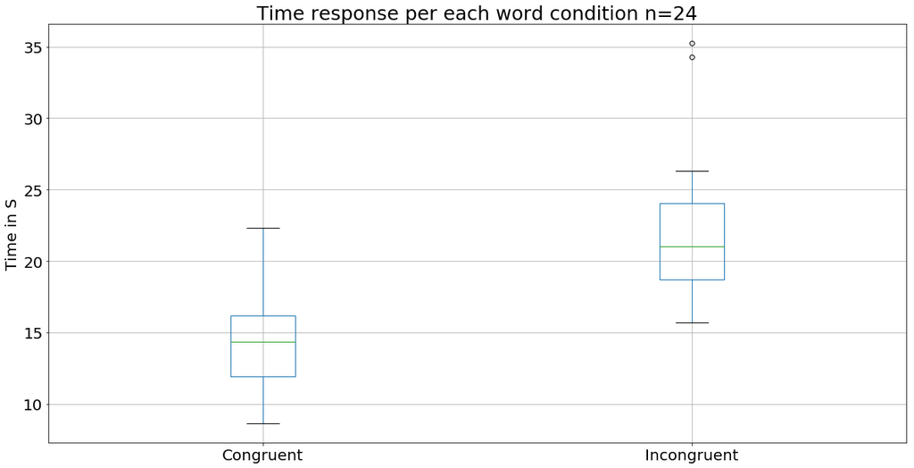

```python
df.boxplot(return_type='axes',figsize=(20,10),fontsize=20);
plt.title('Time response per each word condition n=24',fontsize=25);
plt.ylabel('Time in S',fontsize=20);
plt.show()
```

> the scatter plots shows us the distribtuon of each condition of words.

> the boxplot shows us the distribution of each one as well by showing us the five numbers the max,min and the three quartiles. by looking at the boxplot we can tell that the average of the Incogruent words is bigger than the Congruent.

(5) Now, perform the statistical test and report your results. What is your confidence level or Type I error associated with your test? What is your conclusion regarding the hypotheses you set up? Did the results match up with your expectations? **Hint:** Think about what is being measured on each individual, and what statistic best captures how an individual reacts in each environment.

> we will make a two-tailed test to check the significance of the difference.

> the alpha/confidence level is : 5%.

> the alpha critical values are : **-2.069** and **2.069** since we have 23 degrees of freedom.

```python
# first off we will find the t-statestic to find if the
# different in means
import math
from scipy import stats
n = 24
m_d = df['Incongruent'].mean() - df['Congruent'].mean() # means difference
d_m = df['Incongruent'] - df['Congruent'] # differance of each mean
s = d_m.std(ddof=1) # standard deviation of the sample
t_value = m_d/(s/math.sqrt(n))
p_value = stats.t.sf(np.abs(t_value), n-1)*2
```

```python
t_value
```

```
8.020706944109957
```

```python
p_value
```

```
4.1030005857111781e-08
```

> the T-Value is pretty far from the right side critical value, and the p-value is totally less than 2.5%. hence, we would ignore the Null hypothesis and cosider the alternative.

(6) Optional: What do you think is responsible for the effects observed? Can you think of an alternative or similar task that would result in a similar effect? Some research about the problem will be helpful for thinking about these two questions!